# Demographics factors

## `get_demographics` function

https://github.com/IanEisenberg/Self_Regulation_Ontology/blob/master/selfregulation/utils/utils.py#L241

- Arguments:
- dataset=None,
- cleanup=True,
- num_response_thresh=10,
- drop_categorical=True, verbose=False
- Procedure:
- read in `demographic_health.csv`
- replace `WeightPounds<50` with NA
- replace `HeightInches<36` with NA
- replace `CaffienatedSodaCansPerDay<0` with NA
- replace `CaffieneOtherSourcesDayMG>2000` with NA
- create `BMI` column `BMI=demogdata['WeightPounds']*0.45 / (demogdata['HeightInches']*0.025)**2`
- drop categorical vars categorical_vars = [‘HispanicLatino’,‘Race’, ‘DiseaseDiagnoses’, ‘DiseaseDiagnosesOther’, ‘MotivationForParticipation’, ‘MotivationOther’, ‘NeurologicalDiagnoses’, ‘NeurologicalDiagnosesDescribe’, ‘OtherDebtSources’, ‘OtherDrugs’, ‘OtherRace’, ‘OtherTobaccoProducts’, ‘PsychDiagnoses’, ‘PsychDiagnosesOther’]
- create `Obese` column `demogdata['BMI']>30)`
- only keep variables with fewer NaNs then num_response_thresh
- Output:

```r
get_demographics = function(dataset=NA, cleanup=TRUE, num_response_thresh=10, drop_categorical=TRUE){
  require(tidyverse)

  data = read.csv(dataset)

  if(cleanup){
    data = data %>%
      mutate(WeightPounds = ifelse(WeightPounds<50, NA, WeightPounds),
             HeightInches = ifelse(HeightInches<36, NA, HeightInches),
             CaffienatedSodaCansPerDay = ifelse(CaffienatedSodaCansPerDay < 0, NA, CaffienatedSodaCansPerDay),
             CaffieneOtherSourcesDayMG = ifelse(CaffieneOtherSourcesDayMG>2000, NA, CaffieneOtherSourcesDayMG),
             BMI = WeightPounds*0.45/(HeightInches*0.025)^2,
             Obese = ifelse(BMI>30, 1, 0)) %>%
      select(-WeightPounds, -HeightInches)
  }

  categorical_vars = c('HispanicLatino','Race',
                        'DiseaseDiagnoses', 'DiseaseDiagnosesOther',
                        'MotivationForParticipation', 'MotivationOther',
                        'NeurologicalDiagnoses',
                        'NeurologicalDiagnosesDescribe',
                        'OtherDebtSources',
                        'OtherDrugs', 'OtherRace', 'OtherTobaccoProducts',
                        'PsychDiagnoses',
                        'PsychDiagnosesOther')

  if(drop_categorical){
    data = data %>%
      select(-one_of(categorical_vars))
  }

  if(num_response_thresh>0){
    data = data %>%
      select(which(colMeans(is.na(.)) < num_response_thresh/nrow(.)))
  }

  return(data)
}
```

```r
data_path = '/Users/zeynepenkavi/Documents/PoldrackLabLocal/Self_Regulation_Ontology/Data/'
release = 'Complete_03-29-2018/'
dataset = 'demographic_health.csv'

demographics = get_demographics(dataset = paste0(data_path, release, dataset))

demographics
```

| X | Sex | Age | HighestEducation | RelationshipStatus | DivorceCount | LongestRelationship | RelationshipNumber | ChildrenNumber | HouseholdIncome | RetirementAccount | RentOwn | CoffeeCupsPerDay | TeaCupsPerDay | CaffienatedSodaCansPerDay | CaffieneOtherSourcesDayMG | GamblingProblem | TrafficTicketsLastYearCount | TrafficAccidentsLifeCount | ArrestedChargedLifeCount | LifetimeSmoke100Cigs | HowLongSmoked | SmokeEveryDay | CigsPerDay | HowSoonSmokeAfterWaking | AlcoholHowOften | AlcoholHowManyDrinksDay | AlcoholHowOften6Drinks | HowOftenCantStopDrinking | HowOftenFailedActivitiesDrinking | … |
| --- | --- | --- | --- | --- | --- | --- | --- | --- | --- | --- | --- | --- | --- | --- | --- | --- | --- | --- | --- | --- | --- | --- | --- | --- | --- | --- | --- | --- | --- | --- |
| s001 | 1 | 27 | 3 | 2 | 0 | 84 | 1 | 1 | 40000 | 1 | 1 | 1 | 0 | 0 | 0 | 0 | 0 | 1 | 0 | 1 | 6 | 2 | 1 | 0 | 2 | 2 | 1 | 0 | 0 | … |
| s002 | 0 | 35 | 2 | 2 | 0 | 216 | 1 | 3 | 19500 | 0 | 1 | 3 | 0 | 0 | 0 | 0 | 0 | 3 | 0 | 1 | 7 | 3 | 5 | 1 | 1 | 1 | 0 | 0 | 0 | … |
| s003 | 0 | 25 | 4 | 1 | 0 | 26 | 1 | 0 | 60000 | 0 | 0 | 1 | 0 | 0 | 90 | 0 | 0 | 1 | 0 | 0 | 0 | 0 | 0 | 0 | 2 | 1 | 1 | 0 | 0 | … |
| s004 | 0 | 35 | 4 | 1 | 0 | 36 | 3 | 0 | 81000 | 0 | 1 | 0 | 0 | 0 | 0 | 0 | 0 | 0 | 0 | 0 | 0 | 0 | 0 | 0 | 2 | 2 | 1 | 0 | 0 | … |
| s005 | 0 | 36 | 3 | 1 | 0 | 18 | 5 | 0 | 36000 | 0 | 0 | 0 | 0 | 0 | 0 | 1 | 0 | 3 | 5 | 1 | 7 | 2 | 2 | 4 | 3 | 3 | 1 | 0 | 2 | … |
| s006 | 1 | 33 | 5 | 2 | 0 | 144 | 3 | 3 | 100000 | 0 | 1 | 1 | 0 | 0 | 0 | 0 | 0 | 0 | 0 | 1 | 1 | 1 | 1 | 5 | 4 | 2 | 1 | 1 | 1 | … |
| s007 | 1 | 32 | 3 | 1 | 0 | 84 | 3 | 3 | 98000 | 0 | 1 | 0 | 0 | 0 | 0 | 0 | 0 | 3 | 0 | 0 | 0 | 0 | 0 | 0 | 0 | 1 | 0 | 0 | 0 | … |
| s008 | 1 | 32 | 4 | 2 | 0 | 156 | 2 | 0 | 80000 | 1 | 0 | 0 | 0 | 6 | 100 | 0 | 0 | 2 | 0 | 0 | 0 | 0 | 0 | 0 | 2 | 1 | 1 | 0 | 0 | … |
| s009 | 0 | 26 | 4 | 3 | 0 | 17 | 3 | 0 | 8000 | 0 | 0 | 1 | 2 | 0 | 0 | 0 | 0 | 0 | 0 | 0 | 0 | 0 | 0 | 0 | 4 | 3 | 1 | 0 | 0 | … |
| s010 | 0 | 44 | 4 | 1 | 0 | 12 | 4 | 0 | 39000 | 0 | 0 | 0 | 0 | 1 | 0 | 0 | 0 | 0 | 0 | 1 | 7 | 1 | 0 | 0 | 2 | 5 | 3 | 1 | 2 | … |

[output cut: 512 more lines]

## `residualize_baseline` function

https://github.com/IanEisenberg/Self_Regulation_Ontology/blob/master/dimensional_structure/utils.py#L479

- Arguments:
- df
- baseline vars: [‘Age’, ‘Sex’]
- Procedure:
- create df with baseline vars extracted from df
- remove baseline vars from df to create data df
- impute data df if there is missing data using `fancyimpute` `SimpleFill()`
- for each variable v in data df regress v ~ Age+Sex
- new v = v - predicted v using empirical Age+Sex
- Output:
- data with columns that have the effect of Age and Sex residualized out

```r
residualize_baseline = function(df, baseline_vars = c("Age", "Sex")){
  require(tidyverse)
  require(broom)

  X = df %>%
    select(one_of(baseline_vars))

  Y = df %>%
    select(-one_of(c("X", baseline_vars)))


  for(v in names(Y)){
    tmp = cbind(X, Y %>% select(v))
    m = lm(as.formula(paste(v,' ~ .')), tmp)
    tmp$v_pred = tmp[,v] - predict(m)
    Y[,v] = tmp$v_pred
  }

  return(Y)

}
```

```r
res_demographics = residualize_baseline(demographics)
```

## `Demographic Analysis` class

https://github.com/IanEisenberg/Self_Regulation_Ontology/blob/master/dimensional_structure/results.py#L463

- Arguments:
- subclass of `EFA_Analysis` class
- data, residualize=True, residualize_vars=[‘Age’, ‘Sex’], boot_iter=1000
- Procedures:
- calls `residualize_baseline`
- (for change in retest data also calls `get_demographics` function)
- `Results` class calls the Demographic Analysis class for its DA attribute with data read is using `get_demographics`
- `EFA_Analysis` –>
  - `run` –>
  - `get_dimensionality` –> **`find_optimal_components`** –> `psychFA` looping through a range of factor numbers –> returns `best_c` (number of optimal components) and `metrics` df of fit statistic for each number of components
  - `get_loadings` –> if no factor solution has been computed runs `psychFA` with the optimal number of components
  - `computer_higher_order_factors` –> runs `find_optimal_components` and `psychFA` on the correlation matrix of subject level **`psychFA`** scores
  - `get_factor_entropies`

```r
psych::fa(data, n_components, rotate='oblimin', fm='ml', n_obs=0,
                      scores='tenBerge')
```

```r
find_optimal_components = function(data, minc=1, maxc=50){

  require(tidyverse)

  steps_since_best = 0 # count steps since last best metric.
  maxc = min(maxc, dim(data)[2])
  n_components = seq(minc,maxc)
  metrics = data.frame(comp=n_components, BIC = NA)
  best_metric = NA
  best_c = 0

  for(cur_c in n_components){
    out = psych::fa(data, cur_c, rotate='oblimin', fm='ml', scores='tenBerge')
    if(is.null(out$BIC)){
      curr_metric = NA
    }
    else{
      curr_metric = out$BIC
    }

    metrics$BIC[which(metrics$comp == cur_c)] = curr_metric
  }

  metrics = metrics %>% arrange(BIC)

  return(metrics)
}
```

```r
demog_comp_metrics = find_optimal_components(res_demographics)

demog_comp_metrics
```

| comp | BIC |
| --- | --- |
| 9 | -3676.40350 |
| 8 | -3673.76851 |
| 7 | -3665.14814 |
| 10 | -3598.28483 |
| 6 | -3580.98280 |
| 11 | -3513.57516 |
| 12 | -3400.82929 |
| 5 | -3342.10463 |
| 13 | -3274.53172 |
| 14 | -3151.54069 |

[output cut: 40 more lines]

```r
demog_fa = psych::fa(res_demographics, demog_comp_metrics$comp[1], rotate='oblimin', fm='ml', scores='tenBerge')
```

```r
demog_fa_loadings = data.frame(demog_fa$loadings[]) %>%
  mutate(dv = row.names(.)) %>%
  select(dv,everything()) %>%
  rename(Daily_Smoking=ML1,
       Lifetime_Smoking=ML2,
       Problem_Drinking=ML3,
       Mental_Health = ML4,
       Drug_Use = ML5,
       Obesity = ML6,
       Binge_Drinking=ML7,
       Unsafe_Drinking=ML8,
       Income_LifeMilestones=ML9)

demog_fa_loadings
```

| dv | Drug_Use | Mental_Health | Problem_Drinking | Daily_Smoking | Binge_Drinking | Obesity | Lifetime_Smoking | Unsafe_Drinking | Income_LifeMilestones |
| --- | --- | --- | --- | --- | --- | --- | --- | --- | --- |
| HighestEducation | 0.013046234 | 0.017173387 | -0.0162197497 | -0.0344426287 | 0.118371259 | -0.130775683 | -0.037569210 | 0.040609379 | 0.283794825 |
| RelationshipStatus | -0.032117561 | -0.143716799 | 0.0210263226 | -0.0176429010 | 0.048102546 | 0.035065718 | 0.068976590 | -0.030628684 | 0.110347879 |
| DivorceCount | -0.073588347 | -0.001918136 | -0.0101170712 | 0.0092067942 | -0.167420181 | -0.045298239 | 0.064971745 | 0.121075101 | -0.109915268 |
| LongestRelationship | -0.005978993 | -0.052496772 | 0.0271164521 | 0.0622019471 | -0.017614414 | 0.069673450 | 0.084481134 | -0.113810654 | 0.277442277 |
| RelationshipNumber | -0.009988091 | -0.095828686 | -0.1224030511 | -0.0215480879 | 0.135293476 | -0.145205920 | 0.177868936 | 0.245410218 | -0.047047914 |
| ChildrenNumber | -0.035282639 | -0.068312893 | -0.0111792312 | 0.1802984749 | -0.095826164 | 0.094696976 | 0.071724794 | -0.020355849 | 0.265404475 |
| HouseholdIncome | -0.004197594 | -0.000820929 | -0.0152446955 | -0.0321076183 | 0.038833872 | 0.002929803 | 0.011006001 | -0.008824787 | 0.748151009 |
| RetirementAccount | -0.019058988 | -0.039132363 | 0.0045378288 | -0.0104818537 | -0.016229798 | 0.023137887 | -0.024058538 | 0.086373602 | 0.521157816 |
| RentOwn | 0.039499625 | -0.019138596 | 0.0557827817 | 0.0621357558 | -0.092759184 | -0.005426964 | -0.023202968 | -0.090798387 | 0.307673949 |
| CoffeeCupsPerDay | 0.134062655 | 0.029521884 | -0.1314341933 | 0.2126525059 | 0.048657352 | 0.013843392 | 0.005448798 | 0.072808196 | -0.009703887 |

[output cut: 41 more lines]

```r
demog_fa_scores = data.frame(demog_fa$scores[]) %>%
  mutate(sub_id = demographics$X) %>%
  select(sub_id,everything()) %>%
  rename(Daily_Smoking=ML1,
       Lifetime_Smoking=ML2,
       Problem_Drinking=ML3,
       Mental_Health = ML4,
       Drug_Use = ML5,
       Obesity = ML6,
       Binge_Drinking=ML7,
       Unsafe_Drinking=ML8,
       Income_LifeMilestones=ML9)

demog_fa_scores
```

| sub_id | Drug_Use | Mental_Health | Problem_Drinking | Daily_Smoking | Binge_Drinking | Obesity | Lifetime_Smoking | Unsafe_Drinking | Income_LifeMilestones |
| --- | --- | --- | --- | --- | --- | --- | --- | --- | --- |
| s001 | -0.253580167 | 3.076052139 | -0.3759171427 | 0.9997694470 | 0.48439588 | -0.94322472 | 1.22139262 | 0.0604327480 | 0.479956488 |
| s002 | -0.480754913 | -0.436258930 | -0.4364081445 | 1.8866452572 | -1.01312389 | 1.30174161 | 1.14249717 | -0.3267178281 | -0.331971562 |
| s003 | 5.573827767 | -0.268689342 | -0.6042951665 | -0.5404532788 | 0.04939597 | -0.56367825 | -0.83040236 | -0.0296873352 | 0.379183066 |
| s004 | -0.454229884 | -0.850069179 | -0.4432480658 | -0.6547037853 | 0.40696054 | -0.38779808 | -1.03118208 | -0.2012904832 | 0.707389039 |
| s005 | 0.990333189 | 0.008558065 | 1.6577130992 | 0.9282463476 | 0.53608430 | -0.82382259 | 1.07166526 | -0.0790872418 | -1.292674488 |
| s006 | -0.178918963 | -0.983827274 | 1.7467882798 | 0.1163284650 | 0.70424088 | -0.68174712 | 0.91231242 | -0.1017906686 | 2.202895712 |
| s007 | -0.094324560 | -0.119161168 | -0.1523209579 | -0.6126623414 | -0.72614536 | -0.78914179 | -1.02592004 | -0.1255215645 | 1.261262760 |
| s008 | -0.131955527 | 0.484789600 | -0.3187347291 | -0.6249291583 | 0.48601375 | 2.03671245 | -1.01208067 | 0.0187675747 | 1.142713632 |
| s009 | -0.575861718 | -0.736824186 | 0.0775104821 | -0.5273773403 | 0.75753899 | 1.21564371 | -0.70882231 | 0.0466831200 | -0.700160490 |
| s010 | -0.401710043 | -0.366645659 | 1.8792427492 | -0.1366664112 | 2.64845796 | -0.67722696 | 0.78774337 | -0.4412688195 | -1.270550632 |

[output cut: 512 more lines]

```r
ian_demog = read.csv('/Users/zeynepenkavi/Downloads/demo_factors.csv')
ian_demog = ian_demog %>%
  rename(sub_id = X,
         Drug_Use = Drug.Use,
         Mental_Health = Mental.Health,
         Problem_Drinking = Problem.Drinking,
         Daily_Smoking = Daily.Smoking,
         Binge_Drinking = Binge.Drinking,
         Lifetime_Smoking = Lifetime.Smoking,
         Unsafe_Drinking = Unsafe.Drinking,
         Income_LifeMilestones = Income...Life.Milestones) %>%
  mutate(exec = 'ian')
```

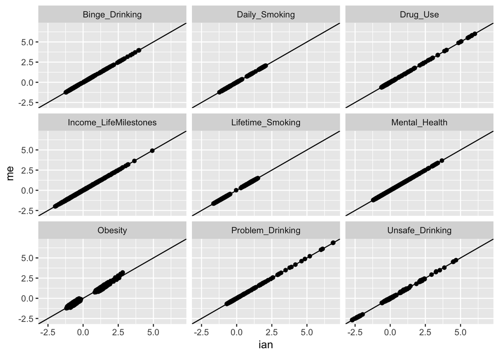

```r
demog_fa_scores %>%
  mutate(exec = "me") %>%
  rbind(.,ian_demog) %>%
  gather(key, value, -sub_id, -exec) %>%
  spread(exec, value) %>%
  ggplot(aes(ian, me))+
  geom_point()+
  geom_abline(intercept=0, slope=1)+
  facet_wrap(~key)
```